# 1 Display the Game

I’ve chosen the *Simple and Fast Multimedia Library* [SFML](https://www.sfml-dev.org/index.php) for creating the graphical user interface of the app. It lives up to its name and is available on all major platforms and programming languages.

In this chapter we’ll learn how to display the board and the chess pieces on it. In order to show valid moves for each piece, we will also learn the basic rules of the game.

I’m using [CMake](https://cmake.org/) for building the C<sup>++</sup> code, and the SFML CMake project template, which will build the SFML libraries. So you will need to have the following components installed on your machine:

- a decent C<sup>++</sup> compiler (any of the major compilers will do)
- the *git* tool
- the *cmake* tool
- the required system packages for [SFML](https://www.sfml-dev.org/tutorials/2.6/start-cmake.php)

On a Linux system, all those components can be installed with your systems package manager (e.g. with `apt-get` on Ubuntu). For Mac OS, just use the included `clang++` compiler and install missing components with [homebrew](https://brew.sh/): `brew install git cmake sfml`.

When everything is in place, just clone my repository with `git clone https://github.com/okrischer/ThinkChess.git` and execute `cmake -B build` from the root folder of your local copy. If everything went well, change to the `build` folder and execute `cmake –build .`. Voila, you have a simple chess app, which you can start with `./ThinkChess`.

I strongly encourage you to code all the following steps with an editor of your choice for yourself and see if you can get the code running. Nothing is gained if you just skim over the provided source code.

If you have LaTeX installed on your machine, you can also build the documentation with `pdflatex -shell-escape ThinkChess++.tex` from the `doc` folder, which will produce this document.

Starting with chapter 4, I’ve changed the documentation format to `markdown`, from which you can create a standalone html-document with `pandoc -dhtml`, once you have the versatile conversion tool [pandoc](https://pandoc.org/) installed.

## 1.1 Displaying the board and the pieces

Let’s start with the basic framework for displaying something with SFML:

```cpp
#include <SFML/Graphics.hpp>

int main() {
  sf::ContextSettings settings;
  settings.antialiasingLevel = 8;

  auto window = sf::RenderWindow{ {640u, 640u},
                "ThinkChess++",
                sf::Style::Default, settings };

  window.setFramerateLimit(10);

  while (window.isOpen()) {
    for (auto event = sf::Event{}; window.pollEvent(event);) {
      if (event.type == sf::Event::Closed) {
        window.close();
      }
    }
    window.draw(bs);
    window.display();
  }
}
```

This is the main file for our app (`app/main.cpp`). Thus, it defines the `int main()` function (3) as the starting point of the app (*note*: the numbers in parenthesis `(x)` always refer to the last code snippet).

In order to access SFML functionality, we have to `#include` the SFML Graphics library (1), which was built by *cmake*.

First, we define the context (4) and set the antialiasing level to 8 within the context (5). Next, we define the main window for our app (6), setting its size, title, style, and the context settings. Then we set the framerate to 10 (8), i.e. 10 frames per second; we don’t need more for such a static app, and the app will keep responsive with that. Next comes the central part: entering the main game loop (10-18).  
The game loop usually contains three steps:

1. an event loop, processing all user inputs for the current frame (11-15)
2. several drawing instructions (16) for all items to appear in the frame
3. a call to `window.display()`, which causes all drawn elements to be actually displayed.

### 1.1.1 The board

We don’t have anything to draw yet; let’s change this by adding a chessboard within the main function, just before entering the game loop:

```cpp
sf::Texture bi;
bi.loadFromFile("../img/chessboard.jpg");
sf::Sprite bs; bs.setTexture(bi);
```

Here, we create a SFML texture (1) and load an image from the file system into that texture (2).  
Then we create a SFML sprite (3) and set its texture to that image (4).

If you run the app now, you would see an empty chess board:

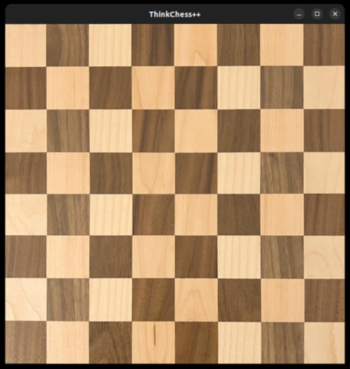

### 1.1.2 The pieces

Not that interesting so far, so we’re going to add the chess pieces at their initial position. For that, let’s introduce the pieces at first: they come in two colors, *white* and *black*, each for one player, and they are called as follows (from left to right in the image below):

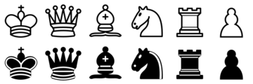

| Piece | King | Queen | Bishop | Knight | Rook | Pawn |
| --- | --- | --- | --- | --- | --- | --- |
| quantity | 1 | 1 | 2 | 2 | 2 | 8 |
| value | - | 8 | 3 | 3 | 4 | 1 |

Every piece, except the king, has a value assigned to it. This is just by convention and not necessary for the original game play. The value indicates the strength of the piece and serves for a basic evaluation of each players position during the game.

The *Queen* is the most powerful piece in the game, followed by the *Rook*; those two are also called *major pieces*.  
Then we have the *Bishop* and the *Knight*, both of equal value, building the group of *minor pieces*.  
The least worthy piece is the *Pawn*.

But why has the *King* no value assigned?  
The goal of the game is to put your opponents *King* in a position, where it is attacked by any of your own pieces (an attack is the threat to capture a piece with the next move). We call this position *check*.  
If a player cannot respond to a *check* in the very next move (i.e. defend his *King*), the game is over, and that player has lost the game. We call this position *checkmate*.  
Thus, the *King* is never actually captured, it stays on the board until the end of the game. With that, it doesn’t make any sense to give it a value for evaluating a players position.

We’ll cover the movement of the pieces in great detail in the section about valid moves. But, for now, let’s concentrate on how to display the pieces:

```cpp
sf::Texture figures;
figures.loadFromFile("../img/figures.png");

sf::Sprite wk; wk.setTexture(figures);
wk.setTextureRect(sf::IntRect(0,0,60,60));

sf::Sprite bk; bk.setTexture(figures);
bk.setTextureRect(sf::IntRect(0,60,60,60));
// --- snip ---
```

We have loaded a texture, containing the figures of all pieces (2). Then we define distinct sprites for every piece, calling them *wk* for the white king (4), *bk* for the black king (8), and so forth.  
Finally, we cut out the matching parts of the `figures` texture and assign them to every distinct sprite (6, 10).

Notice, that I’ve taken care that all the sprites have the same size of $60 × 60$ pixels. As the board has a size of $640 × 640$ pixels, containing $8 × 8$ light and dark squares, every square on the board has a size of $80 × 80$ pixels. That allows us to place the sprites evenly on the board with an offset of 10 pixels to the boundary of each square.

### 1.1.3 Keeping track of the pieces

In order to actually place the pieces on the board, we need a data structure, being able to keep track of the 64 squares. As it turns out, an $8 × 8$ vector matrix is a good fit for that: `vector<vector<Piece*>> board(8, vector<Piece*>(8))`.

We could have used any type of vector matrix for keeping track of the pieces, but I’ve chosen an *object-oriented* approach:  
every piece is represented by a raw pointer (indicated with the *) to an instance of the type `Piece`. That allows for greater flexibility implementing the game logic: instead of putting the logic for the pieces in the main file, we are going to implement it in a new file `app/pieces.cpp`.

So, let’s have a look on how `Piece` is actually implemented:

```cpp
#pragma once
#include <vector>

using namespace std;

// public interface for pieces
class Piece {
public:
  virtual ~Piece() {}
  virtual char getType() = 0;
  virtual char getValue() = 0;
  virtual bool isWhite() = 0;
  virtual bool isCaptured() = 0;
  virtual int getRow() = 0;
  virtual int getCol() = 0;
  virtual void capture() = 0;
  virtual bool isValid(vector<vector<Piece*>>& bd, int r, int c) = 0;
};
```

As you may have guessed, this code snippet is not from the `pieces.cpp` file, but from its *header* file, located at `include/pieces.hpp`. I’ve decided to separate the compilation units into a public interface (the header file) and an implementation file. That allows to use the definitions of the header file in any other implementation file and gives us even more flexibility in structuring the source code.

`Piece` is declared as a pure *abstract* interface. That means, it doesn’t have a *constructor*, and all the member functions are marked as `virtual`. Thus, you cannot instantiate it directly, and to make any use of it, we have to create *derived* classes (subclasses of`Piece`) for every piece, which will implement the virtual functions. The reason for doing so is: we need different implementations for performing moves for each piece, but also a common type for storing them in the board matrix.

The concrete types for `Piece` are implemented like so:

```cpp
class King : public Piece {
public:
  ~King() {}
  King(bool w, int r, int c) : type{'K'}, white{w}, value{0},
                              captured{false}, row{r}, col{c} {}

  char getType() override { return type; }
  char getValue() override { return value; }
  bool isWhite() override { return white; }
  bool isCaptured() override { return captured; }
  int getRow() override { return row; }
  int getCol() override { return col; }
  bool isValid(std::vector<std::vector<Piece*>>& bd, int r, int c)
    override;

private:
  char type;
  bool white;
  short value;
  bool captured;
  int row;
  int col;
};
```

The other pieces are implemented likewise; the only difference between them so far is the implementation of the member function `isValid` (13). I decided to leave all the class definitions in the header file, and moved only the implementation for `isValid` to the file `app/pieces.cpp`.

For now, we are only interested in the type definitions:  
each of them is derived from `class Piece` (1) and has a *destructor* (3), which will be called by the compiler when an instance of the class is destroyed. This will happen automatically, whenever an *automatic* variable gets out of scope. But, if a reference to an instance was created explicitly (using the keyword `new`), we have to `delete` that object explicitly in order to avoid *memory leaks*.

Next, we have the *constructor* (4-5):  
it initializes a new instance with its type (which we need only for drawing the correct sprite), the color of the piece (white or black), its value, and the current position of the piece (the row and column of the piece in the board matrix).

The following member functions (7-12) are just *getters* to retrieve the `private` member types.

With the derived `Piece` types in place, we can initially fill the board matrix:

```cpp
void reset_board(vector<vector<Piece*>>& bd) {
  for (auto rank : bd) {
    for (auto piece : rank) {
      delete piece;
    }
  }
  // rank 8 (black)
  bd[0][0] = new Rook(0,0,0);
  bd[0][1] = new Knight(0,0,1);
  bd[0][2] = new Bishop(0,0,2);
  bd[0][3] = new Queen(0,0,3);
  bd[0][4] = new King(0,0,4);
  bd[0][5] = new Bishop(0,0,5);
  bd[0][6] = new Knight(0,0,6);
  bd[0][7] = new Rook(0,0,7);
  // rank 7 (black)
  bd[1][0] = new Pawn(0,1,0);
  bd[1][1] = new Pawn(0,1,1);
  bd[1][2] = new Pawn(0,1,2);
  bd[1][3] = new Pawn(0,1,3);
  bd[1][4] = new Pawn(0,1,4);
  bd[1][5] = new Pawn(0,1,5);
  bd[1][6] = new Pawn(0,1,6);
  bd[1][7] = new Pawn(0,1,7);
  // rank 2 (white)
  bd[6][0] = new Pawn(1,6,0);
  bd[6][1] = new Pawn(1,6,1);
  bd[6][2] = new Pawn(1,6,2);
  bd[6][3] = new Pawn(1,6,3);
  bd[6][4] = new Pawn(1,6,4);
  bd[6][5] = new Pawn(1,6,5);
  bd[6][6] = new Pawn(1,6,6);
  bd[6][7] = new Pawn(1,6,7);
  // rank 1 (white)
  bd[7][0] = new Rook(1,7,0);
  bd[7][1] = new Knight(1,7,1);
  bd[7][2] = new Bishop(1,7,2);
  bd[7][3] = new Queen(1,7,3);
  bd[7][4] = new King(1,7,4);
  bd[7][5] = new Bishop(1,7,5);
  bd[7][6] = new Knight(1,7,6);
  bd[7][7] = new Rook(1,7,7);
}
```

That seems tedious, but thankfully we have to do this only once. I’ve placed the initialization code within a function `void reset_board`, just in case we want to reset the board later (e.g. when starting a new game). The board is passed as an automatic reference to the function (indicated by the & after the parameter type), such that we are able to modify the board directly, instead of working with a copy of the board.

The code in the first three lines actually resets the board by deleting all existing references to pieces. When setting the pieces, you have to be careful: every piece must be initialized with exactly the same coordinates from the board (and of course with the correct color: 0 for black and 1 for white).

The rows of a chessboard are called *ranks*, while the columns are called *files*. The ranks are indicated by the numbers 1 to 8, whereas the files are indicated by the letters `a` to `h`, both starting at the lower left square (the dark field `a1`):

```
8 . . . . . . . .
7 . . . . . . . .
6 . . . . . . . .
5 . . . . . . . .
4 . . . . . . . .
3 . . . . . . . .
2 . . . . . . . .
1 . . . . . . . .
  a b c d e f g h
```

With the initialization code above, the pieces will be placed like so on the board:

```
8 R N B Q K B N R
7 P P P P P P P P
6 . . . . . . . .
5 . . . . . . . .
4 . . . . . . . .
3 . . . . . . . .
2 P P P P P P P P
1 R N B Q K B N R
  a b c d e f g h
```

Observe that we abbreviate the *Knight* with the letter `N` to avoid confusion with the *King*. So, the white *Queen* is placed at `d1`, the black *Queen* at `d8`, and so forth.

### 1.1.4 Drawing the pieces

Now we can use the filled board matrix to actually draw the pieces within the game loop of the main function:

```cpp
// draw board
window.draw(bs);
// draw pieces
for (int row = 0; row < 8; row++) {
  for (int col = 0; col < 8; col++) {
    if (board[row][col]) {
      auto piece = board[row][col];
      sf::Sprite pc;
      switch (piece->getType()) {
      case 'K':
        piece->isWhite() ? pc = wk : pc = bk;
        break;
      case 'Q':
        piece->isWhite() ? pc = wq : pc = bq;
        break;
      case 'R':
        piece->isWhite() ? pc = wr : pc = br;
        break;
      case 'B':
        piece->isWhite() ? pc = wb : pc = bb;
        break;
      case 'N':
        piece->isWhite() ? pc = wn : pc = bn;
        break;
      case 'P':
        piece->isWhite() ? pc = wp : pc = bp;
        break;
      }
      pc.setPosition(col*80.f + 10.f, row*80.f + 10.f);
      window.draw(pc);
    }
  }
}
```

We are iterating over all elements of the board matrix and get the piece at this position (7). Then we get the type and color of that piece by calling the appropriate getter functions (`getType(), isWhite()`) on it, and let a newly created sprite `pc` point to the corresponding figure sprite (9-28). Finally, we set the correct postion of the `pc` sprite on the board (29) and draw it to the current frame buffer (30).

Observe that we have to use the pointer notation `->` (instead of a dot) for calling those functions on a piece, as the pieces were actually defined as pointers.

And that’s it: when you start the app now, you will see this screen, which shows a correct initialized chessboard with all pieces:

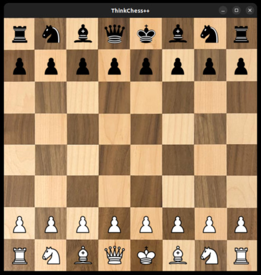

## 1.2 Showing valid moves

The goal for this section is to show the valid moves for any given piece on the board.

### 1.2.1 Game mechanics

For reaching our goal, we first need a way to process user input. With SFML this is done inside the event loop of the main function:

```cpp
// in event loop
// mouse button pressed
if (event.type == sf::Event::MouseButtonPressed) {
  if (event.mouseButton.button == sf::Mouse::Right) {
    pair<int, int> f =
      getField(event.mouseButton.x, event.mouseButton.y);
    setValidMoves(board, board[f.first][f.second]);
  }
}
// mouse button released
if (event.type == sf::Event::MouseButtonReleased) {
  if (event.mouseButton.button == sf::Mouse::Right) {
    validMoves =
      vector<vector<short>>(8, vector<short>(8, 0));
  }
}
```

Here, we check if a mouse button is pressed (3). If so, we check wether it’s the right mouse button (4).  
Then, we get the coordinates of the corresponding field on the board (5-6), and fill another vector matrix with the computed valid moves for the piece under the mouse cursor (7).

When the right mouse button is released (11-12), we reset the vector matrix of valid moves (13-14).

In order for that to work, we need the following definitions in the main file, just before entering the main function:

```cpp
vector<vector<short>> validMoves(8, vector<short>(8, 0));

void setValidMoves(vector<vector<Piece*>>& bd, Piece* pc) {
  if (!pc) return;
  for (int row = 0; row < 8; row++) {
    for (int col = 0; col < 8; col++) {
      if (pc->isValid(bd, row, col)) {
        auto current = bd[row][col];
        if (!current) validMoves[row][col] = 1;
        else if (pc->isWhite() != current->isWhite())
          validMoves[row][col] = 2;
      }
    }
  }
}

pair<int, int> getField(int x, int y) {
  int fx = x / 80;
  int fy = y / 80;
  auto field = make_pair(fy, fx);
  return field;
}
```

The work is done inside the `setValidMoves` function (3):  
if there’s no piece at the given coordinates, do nothing (4). Otherwise, iterate over all fields of the board (5-6), and check wether this position can be reached by the piece under the mouse cursor (7). If so, get the piece of the current search position (8).  
If there is no piece at this position, set this position to valid (9). Otherwise, check the color of the current piece and if it’s different from the piece under the cursor (i.e. it can be captured), set it to valid with the special marker 2 (11).

Our *object-oriented* design is starting to pay off, as we don’t need to define any game logic inside the main application file!

The last thing to do, is to draw the content of the `validMoves` vector inside the main game loop (directly after drawing the pieces):

```cpp
// before game loop
sf::CircleShape valid(20.f);

  // inside game loop
  // draw valid moves
  for (int row = 0; row < 8; row++) {
    for (int col = 0; col < 8; col++) {
      if (validMoves[row][col] > 0) {
        valid.setPosition(col*80.f + 20.f, row*80.f + 20.f);
        if (validMoves[row][col] > 1)
          valid.setFillColor(sf::Color(0, 200, 0, 200));
        else valid.setFillColor(sf::Color(100, 200, 0, 100));
        window.draw(valid);
      }
    }
  }
```

We iterate over all fields of the board (6-7), and if `validMoves` contains an entry at this position (8), we set the marker `valid` on the board (9). As an extra feature, we set the marker to a brighter color, if the piece at this postion can be captured (10-11). Finally, we draw the marker on the board (13).

With that, all valid moves for a selected piece are displayed while pressing the right mouse button (with a green circular shape on the board). As soon as you release the mouse botton, the `validMoves` vector is reset, and there’s nothing more to draw for the next frame.

That’s all for the mechanics of the game for now. Of course, we still need to implement the `isValid` function for every piece, which leads us to the next section.